# Inaugural Speeches：Recent Presidents and Their Antecessors

Yuhao Kang (yk2758)

## Where the story begins:

As we all know, United States of American is a young country. But in its 241 years history, US has grown up as the most powerful country all over the world quickly. When we are suprised by its amaziong growing spped, I want to find something also repaidly changed in this country. So I decide to analyse the Presidents’ Inaugural Speeches by comparing recent presidents and their great antecessors, who built the solid foundation of USA. First, let’s take a look at them!

[figure not shown]

*The First 5 Presidens of US*

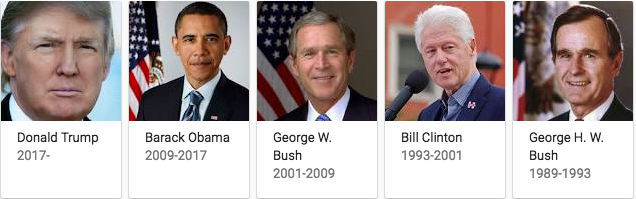

*Recent 5 Presidens of US*

Clearly, their hairstyles changed a lot as time went by. But today, I will focus more on thier **Inaugural Speeches Topics** rather than hairstyle. To realize this analysis, I will use topic modeling method given in last lecture.

### Step 0: Check and install needed packages. Load the libraries and functions.

```r
packages.used=c("rvest", "tibble", "qdap",
                "sentimentr", "gplots", "dplyr",
                "tm", "syuzhet", "factoextra",
                "beeswarm", "scales", "RColorBrewer",
                "RANN", "tm", "topicmodels","tidytext",
                "wordCloud","RColorBrewer", "readxl")
# check packages that need to be installed.
packages.needed=setdiff(packages.used,
                        intersect(installed.packages()[,1],
                                  packages.used))
# install additional packages
if(length(packages.needed)>0){
  install.packages(packages.needed, dependencies = TRUE)
}
# load packages
library("rvest")
library("tibble")
# You may need to run
# sudo ln -f -s $(/usr/libexec/java_home)/jre/lib/server/libjvm.dylib /usr/local/lib
# in order to load qdap
library("qdap")
library("sentimentr")
library("gplots")
library("dplyr")
library("tm")
library("syuzhet")
library("factoextra")
library("beeswarm")
library("scales")
library("RColorBrewer")
library("RANN")
library("tm")
library("topicmodels")
library("tidytext")
library("wordcloud")
library("RColorBrewer")
library("readxl")
source("../lib/plotstacked.R")
source("../lib/speechFuncs.R")
# a function to plot wordcloud of specific speech
source("../lib/speechesCLoud.R")
```

```r
print(R.version)
```

```
               _
platform       x86_64-apple-darwin15.6.0
arch           x86_64
os             darwin15.6.0
system         x86_64, darwin15.6.0
status
major          3
minor          4.3
year           2017
month          11
day            30
svn rev        73796
language       R
version.string R version 3.4.3 (2017-11-30)
nickname       Kite-Eating Tree
```

# Part 1- Topic Analysis of Inaugural Speeches

## 1.1 Data processing – import Data

In this step, we combine the information of each inaugural speeches into one list named **inaug.list**.

```r
### Inauguaral speeches
main.page <- read_html(x = "http://www.presidency.ucsb.edu/inaugurals.php")
# Get link URLs
# f.speechlinks is a function for extracting links from the list of speeches.
inaug=f.speechlinks(main.page)
colnames(inaug) <- c("Date","Links")
# To avoid some problems when we transform the date format.
if(Sys.getlocale("LC_TIME") != "C"){
  Sys.setlocale("LC_TIME","C")
}
```

```
[1] "C"
```

```r
inaug[,1] <-as.Date(inaug[,1], format="%B %e, %Y")
inaug=inaug[-nrow(inaug),] # remove the last line, irrelevant due to error.
# Import the information data of inauguration speeches.
inaug.list <- read_excel("../data/InaugurationInfo.xlsx")
inaug.list <- cbind(inaug.list,inaug)
# Read in full text
inaug.list$fulltext=NA
for(i in seq(nrow(inaug.list))) {
  text <- read_html(inaug.list$Links[i]) %>% # load the page
    html_nodes(".displaytext") %>% # isloate the text
    html_text() # get the text
  inaug.list$fulltext[i]=text
}
head(inaug.list)
```

|  | President | File | Term | Party | Words | Date | Links | fulltext |
| --- | --- | --- | --- | --- | --- | --- | --- | --- |
| 1 | George Washington | GeorgeWashington | 1 | NA | 1431 | 1789-04-30 | http://www.presidency.ucsb.edu/ws/index.php?pid=25800 | Fellow-Citizens of the Senate and of the House of Representatives:Among the vicissitudes incident to life no event could have filled me with greater anxieties than that of which the notification was t… |
| 2 | George Washington | GeorgeWashington | 2 | NA | 135 | 1793-03-04 | http://www.presidency.ucsb.edu/ws/index.php?pid=25801 | Fellow Citizens:I AM again called upon by the voice of my country to execute the functions of its Chief Magistrate. When the occasion proper for it shall arrive, I shall endeavor to express the high s… |
| 3 | John Adams | JohnAdams | 1 | Fedralist | 2321 | 1797-03-04 | http://www.presidency.ucsb.edu/ws/index.php?pid=25802 | WHEN it was first perceived, in early times, that no middle course for America remained between unlimited submission to a foreign legislature and a total independence of its claims, men of reflection … |
| 4 | Thomas Jefferson | ThomasJefferson | 1 | Democratic-Republican Party | 1730 | 1801-03-04 | http://www.presidency.ucsb.edu/ws/index.php?pid=25803 | Friends and Fellow-Citizens:CALLED upon to undertake the duties of the first executive office of our country, I avail myself of the presence of that portion of my fellow-citizens which is here assembl… |
| 5 | Thomas Jefferson | ThomasJefferson | 2 | Democratic-Republican Party | 2166 | 1805-03-04 | http://www.presidency.ucsb.edu/ws/index.php?pid=25804 | PROCEEDING, fellow-citizens, to that qualification which the Constitution requires before my entrance on the charge again conferred on me, it is my duty to express the deep sense I entertain of this n… |
| 6 | James Madison | JamesMadison | 1 | Democratic-Republican Party | 1177 | 1809-03-04 | http://www.presidency.ucsb.edu/ws/index.php?pid=25805 | Unwilling to depart from examples of the most revered authority, I avail myself of the occasion now presented to express the profound impression made on me by the call of my country to the station to … |

## 1.2 Data Processing — generate list of sentences

```r
sentence.list=NULL
for(i in 1:nrow(inaug.list)){
  sentences=sent_detect(inaug.list$fulltext[i],
                        endmarks = c("?", ".", "!", "|",";"))
  if(length(sentences)>0){
    emotions=get_nrc_sentiment(sentences)
    word.count=word_count(sentences)
    # colnames(emotions)=paste0("emo.", colnames(emotions))
    # in case the word counts are zeros?
    emotions=diag(1/(word.count+0.01))%*%as.matrix(emotions)
    sentence.list=rbind(sentence.list,
                        cbind(inaug.list[i,-ncol(inaug.list)],
                              sentences=as.character(sentences),
                              word.count,
                              emotions,
                              sent.id=1:length(sentences)
                              )
    )
  }
}
setwd("~/Documents/GitHub/Spring2018-Project1-htmy102")
# omit NAs
sentence.list$Type = "inaug"
sentence.list=
  sentence.list%>%
  filter(!is.na(word.count))
```

## 1.3 Data analysis — Topic modeling

### 1.3.1 Create snippets corpus

For topic modeling, we prepare a corpus of sentence snippets as follows. For each speech, we start with sentences and prepare a snippet with a given sentence with the flanking sentences. And then we use these snipets to creat our corpus to analysis.

```r
# prepare sentence snippets (3 continuing sentences)
corpus.list=sentence.list[2:(nrow(sentence.list)-1), ]
sentence.pre=sentence.list$sentences[1:(nrow(sentence.list)-2)]
sentence.post=sentence.list$sentences[3:(nrow(sentence.list)-1)]
corpus.list$snippets=paste(sentence.pre, corpus.list$sentences, sentence.post, sep=" ")
# avoid snippets combining senstences from different speeches
rm.rows=(1:nrow(corpus.list))[corpus.list$sent.id==1]
rm.rows=c(rm.rows, rm.rows-1)
corpus.list=corpus.list[-rm.rows, ]
# creat our corpus
docs <- Corpus(VectorSource(corpus.list$snippets))
```

### 1.3.2. Clean our corpus

For this corpus, we remove extra white space, convert all letters to the lower case, remove [stop words](https://github.com/arc12/Text-Mining-Weak-Signals/wiki/Standard-set-of-english-stopwords), removed empty words due to formatting errors, and remove punctuation. Then we compute the [Document-Term Matrix (DTM)](https://en.wikipedia.org/wiki/Document-term_matrix).

```r
#remove potentially problematic symbols
docs <-tm_map(docs,content_transformer(tolower))
docs <- tm_map(docs, removePunctuation)
docs <- tm_map(docs, removeNumbers)
docs <- tm_map(docs, removeWords, stopwords("english"))
docs <- tm_map(docs, stripWhitespace)
docs <- tm_map(docs,stemDocument)
#compute Document-Term Matrix
dtm <- DocumentTermMatrix(docs)
#convert rownames to filenames#convert rownames to filenames
rownames(dtm) <- paste(corpus.list$File,
                       corpus.list$Term, corpus.list$sent.id, sep="_")
rowTotals <- apply(dtm , 1, sum) #Find the sum of words in each Document
dtm  <- dtm[rowTotals> 0, ]
corpus.list=corpus.list[rowTotals>0, ]
```

### 1.3.3 Run LDA topic models

```r
#Set parameters for Gibbs sampling
burnin <- 4000
iter <- 2000
thin <- 500
seed <-list(2003,5,63,100001,765)
nstart <- 5
best <- TRUE
#Number of topics
k <- 15
#Run LDA using Gibbs sampling
ldaOut <-LDA(dtm, k, method="Gibbs", control=list(nstart=nstart,
                                                 seed = seed, best=best,
                                                 burnin = burnin, iter = iter,
                                                 thin=thin))
#write out results
#docs to topics
ldaOut.topics <- as.matrix(topics(ldaOut))
table(c(1:k, ldaOut.topics))
```

```
  1   2   3   4   5   6   7   8   9  10  11  12  13  14  15
395 659 403 383 390 258 244 388 450 457 343 285 259 333 299
```

```r
write.csv(ldaOut.topics,file=paste("../output/LDAGibbs",k,"DocsToTopics.csv"))
#top 6 terms in each topic
ldaOut.terms <- as.matrix(terms(ldaOut,15))
write.csv(ldaOut.terms,file=paste("../output/LDAGibbs",k,"TopicsToTerms.csv"))
#probabilities associated with each topic assignment
topicProbabilities <- as.data.frame(ldaOut@gamma)
write.csv(topicProbabilities,file=paste("../output/LDAGibbs",k,"TopicProbabilities.csv"))
```

## 1.4 Analysis of topics

### 1.4.1 Topics hashtags

```r
terms.beta=ldaOut@beta
terms.beta=scale(terms.beta)
topics.terms=NULL
for(i in 1:k){
  topics.terms=rbind(topics.terms, ldaOut@terms[order(terms.beta[i,], decreasing = TRUE)[1:7]])
}
topics.terms
```

```
      [,1]         [,2]           [,3]          [,4]        [,5]        [,6]            [,7]
 [1,] "session"    "languag"      "conform"     "ordinari"  "opposit"   "lock"          "specif"
 [2,] "togeth"     "challeng"     "job"         "play"      "yes"       "everyon"       "technolog"
 [3,] "texa"       "compos"       "compact"     "deleg"     "dissolv"   "discountenanc" "offspr"
 [4,] "vast"       "north"        "stronger"    "area"      "transport" "ship"          "marin"
 [5,] "profit"     "group"        "count"       "basic"     "deeper"    "complex"       "joy"
 [6,] "understand" "unless"       "loyalti"     "win"       "cabinet"   "steril"        "graviti"
 [7,] "injur"      "mitig"        "apart"       "phrase"    "slowli"    "clean"         "triumphant"
 [8,] "appreci"    "estim"        "repair"      "coordin"   "swear"     "allot"         "post"
 [9,] "god"        "came"         "thank"       "vice"      "heard"     "ceremoni"      "histor"
[10,] "spread"     "relationship" "hatr"        "hate"      "nuclear"   "dawn"          "arsenal"
[11,] "class"      "properti"     "citizenship" "negro"     "crime"     "proposit"      "immigr"
[12,] "evid"       "saw"          "jealousi"    "ascertain" "overlook"  "divert"        "sink"
[13,] "founder"    "inherit"      "virtuous"    "profess"   "circl"     "prudenc"       "aristocraci"
[14,] "tax"        "collect"      "prompt"      "wast"      "taxat"     "treasuri"      "incom"
[15,] "navi"       "suitabl"      "fortif"      "amiti"     "advoc"     "salutari"      "prey"
```

```r
ldaOut.terms
```

```
      Topic 1     Topic 2    Topic 3     Topic 4     Topic 5    Topic 6      Topic 7    Topic 8     Topic 9
 [1,] "upon"      "new"      "govern"    "great"     "life"     "will"       "can"      "shall"     "time"
 [2,] "congress"  "america"  "state"     "countri"   "men"      "everi"      "must"     "duti"      "year"
 [3,] "parti"     "american" "power"     "increas"   "chang"    "good"       "one"      "may"       "day"
 [4,] "made"      "let"      "constitut" "product"   "great"    "now"        "peopl"    "offic"     "histori"
 [5,] "constitut" "work"     "union"     "industri"  "nation"   "need"       "make"     "support"   "first"
 [6,] "question"  "togeth"   "unit"      "commerc"   "without"  "believ"     "other"    "confid"    "now"
 [7,] "execut"    "generat"  "author"    "protect"   "purpos"   "never"      "like"     "faith"     "god"
 [8,] "differ"    "live"     "general"   "territori" "hand"     "futur"      "done"     "servic"    "hope"
 [9,] "legisl"    "old"      "right"     "extend"    "thing"    "nation"     "anoth"    "trust"     "presid"
[10,] "effect"    "promis"   "feder"     "progress"  "individu" "effort"     "take"     "best"      "centuri"
[11,] "may"       "world"    "within"    "trade"     "fear"     "civil"      "strong"   "countri"   "stand"
[12,] "opinion"   "opportun" "object"    "state"     "justic"   "understand" "hold"     "administr" "today"
[13,] "control"   "land"     "limit"     "establish" "polit"    "bring"      "place"    "respons"   "call"
[14,] "principl"  "respons"  "whole"     "improv"    "way"      "follow"     "person"   "oblig"     "come"
```

[output cut: 17 more lines]

```r
topics.hash=c("Military", "WorldPeace", "Time", "Economy",
              "Nation", "Responsibility", "Hope", "Equality",
              "America", "Politic", "WorkingFamilies", "Legislation",
              "Community", "Government", "Patriotism")
corpus.list$ldatopic=as.vector(ldaOut.topics)
corpus.list$ldahash=topics.hash[ldaOut.topics]
colnames(topicProbabilities)=topics.hash
corpus.list.df=cbind(corpus.list, topicProbabilities)
```

### 1.4.2. Clustering of topics

Now we have topics and thier probabilitie given by LDA model. Then we can cluster them.

```r
par(mar=c(1,1,1,1))
topic.summary=tbl_df(corpus.list.df)%>%
              select(File, Military:Patriotism,Date)%>%
              group_by(File)%>%
              summarise_all(funs(mean))
topic.summary=as.data.frame(topic.summary)
rownames(topic.summary)=paste(topic.summary[,1],substr(topic.summary$Date,1,4),sep = "-")
# [1] "Military"   "WorldPeace"  "Time"  "Economy",
# [5] "Nation"  "Responsibility"  "Hope"  "Equality",
# [9] "America"  "Politic"  "WorkingFamilies"  "Legislation",
# [13] "Community"  "Government"  "Patriotism"
topic.plot=c(1 :15)
print(topics.hash[topic.plot])
```

```
 [1] "Military"        "WorldPeace"      "Time"            "Economy"         "Nation"          "Responsibility"
 [7] "Hope"            "Equality"        "America"         "Politic"         "WorkingFamilies" "Legislation"
[13] "Community"       "Government"      "Patriotism"
```

```
Discrepancy: Rowv is FALSE, while dendrogram is `both'. Omitting row dendogram.
```

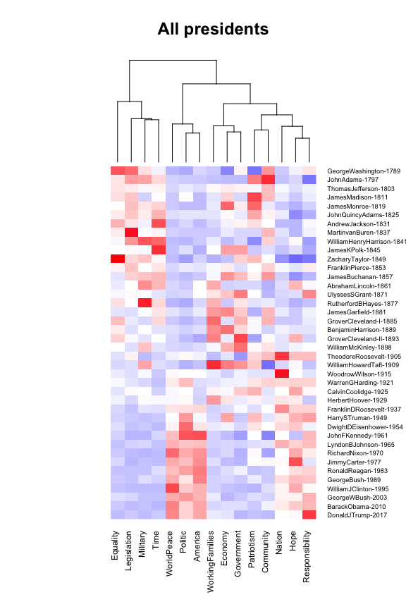

```r
topic.summary <- topic.summary[order(topic.summary$Date,decreasing = F),]
heatmap.2(as.matrix(topic.summary[,topic.plot+1]),
          scale = "column", key=F, Rowv=F,
          col = bluered(100),
          cexRow = 0.7, cexCol = 0.9, margins = c(8, 8),
          trace = "none", density.info = "none",hline = 5,
          main="All presidents")
```

From above clustering fig, as time went by, the topics clustered also changed. For example, in early years, Equality, Legislation and Military are mentioned most.

We can find that the topic they emphasize are different from time to time. To be more clear, we can plot the topic share condition to the next step analysis. So we go to the next step and pick up the most recent 5 presidents, the first 5 presidents and 5 presidents from the middle of timeline.

```r
recent_presidents <- c("GeorgeBush","WilliamJClinton","GeorgeWBush","BarackObama","DonaldJTrump")
middle_presidents <- c("BenjaminHarrison","GroverCleveland-I","WilliamMcKinley",
                       "TheodoreRoosevelt","WilliamHowardTaft")
founding_presidents <- c("GeorgeWashington","JohnAdams","ThomasJefferson","JamesMadison","JamesMonroe")
```

### 1.4.3. Topic shares

```r
# [1] "Military"  "WorldPeace"  "Time"  "Economy",
# [5] "Nation"  "Responsibility"  "Hope"  "Equality",
# [9] "America"  "Politic"  "WorkingFamilies"  "Legislation",
# [13] "Community"  "Government"  "Patriotism"
par(mfcol=c(5, 3), mar=c(1,1,2,0), bty="n", xaxt="n", yaxt="n")
topic.plot=c(1,2,4,5,8,9,10,11,12,15)
print(topics.hash[topic.plot])
```

```
 [1] "Military"        "WorldPeace"      "Economy"         "Nation"          "Equality"        "America"
 [7] "Politic"         "WorkingFamilies" "Legislation"     "Patriotism"
```

```r
for(i in 5:1){
  speech.df=tbl_df(corpus.list.df)%>%filter(File==recent_presidents[i],  Term==1)%>%
    select(sent.id, Military:Patriotism)
  speech.df=as.matrix(speech.df)
  speech.df[,-1]=replace(speech.df[,-1], speech.df[,-1]<1/15, 0.001)
  speech.df[,-1]=f.smooth.topic(x=speech.df[,1], y=speech.df[,-1])
  plot.stacked(speech.df[,1], speech.df[,topic.plot+1],
               xlab="Sentences", ylab="Topic share", main=recent_presidents[i])

}
```

```
 [1] 0.04873561 0.09747122 0.14620682 0.19494243 0.24367804 0.29241365 0.34114926 0.38988487 0.43862047
[10] 0.48735608
 [1] 0.04929198 0.09858397 0.14787595 0.19716794 0.24645992 0.29575191 0.34504389 0.39433588 0.44362786
[10] 0.49291984
 [1] 0.05011103 0.10022207 0.15033310 0.20044414 0.25055517 0.30066621 0.35077724 0.40088828 0.45099931
[10] 0.50111035
 [1] 0.05250434 0.10500868 0.15751302 0.21001737 0.26252171 0.31502605 0.36753039 0.42003473 0.47253907
[10] 0.52504341
 [1] 0.0477493 0.0954986 0.1432479 0.1909972 0.2387465 0.2864958 0.3342451 0.3819944 0.4297437 0.4774930
```

```r
for(i in 5:1){
  speech.df=tbl_df(corpus.list.df)%>%filter(File==middle_presidents[i],  Term==1)%>%
    select(sent.id, Military:Patriotism)
  speech.df=as.matrix(speech.df)
  speech.df[,-1]=replace(speech.df[,-1], speech.df[,-1]<1/15, 0.001)
  speech.df[,-1]=f.smooth.topic(x=speech.df[,1], y=speech.df[,-1])
  plot.stacked(speech.df[,1], speech.df[,topic.plot+1],
               xlab="Sentences", ylab="Topic share", main=middle_presidents[i])

}
```

```
 [1] 0.0500333 0.1000666 0.1500999 0.2001332 0.2501665 0.3001998 0.3502331 0.4002664 0.4502997 0.5003330
 [1] 0.04805998 0.09611996 0.14417993 0.19223991 0.24029989 0.28835987 0.33641985 0.38447982 0.43253980
[10] 0.48059978
 [1] 0.05009139 0.10018277 0.15027416 0.20036555 0.25045693 0.30054832 0.35063970 0.40073109 0.45082248
[10] 0.50091386
 [1] 0.05316295 0.10632590 0.15948885 0.21265179 0.26581474 0.31897769 0.37214064 0.42530359 0.47846654
[10] 0.53162949
 [1] 0.05888221 0.11776443 0.17664664 0.23552885 0.29441106 0.35329328 0.41217549 0.47105770 0.52993992
[10] 0.58882213
```

```
 [1] 0.04495816 0.08991632 0.13487448 0.17983264 0.22479080 0.26974896 0.31470712 0.35966528 0.40462344
[10] 0.44958160
 [1] 0.04552442 0.09104884 0.13657326 0.18209768 0.22762209 0.27314651 0.31867093 0.36419535 0.40971977
[10] 0.45524419
 [1] 0.0535267 0.1070534 0.1605801 0.2141068 0.2676335 0.3211602 0.3746869 0.4282136 0.4817403 0.5352670
 [1] 0.05348099 0.10696197 0.16044296 0.21392394 0.26740493 0.32088592 0.37436690 0.42784789 0.48132887
[10] 0.53480986
 [1] 0.04780256 0.09560511 0.14340767 0.19121022 0.23901278 0.28681533 0.33461789 0.38242044 0.43022300
[10] 0.47802555
```

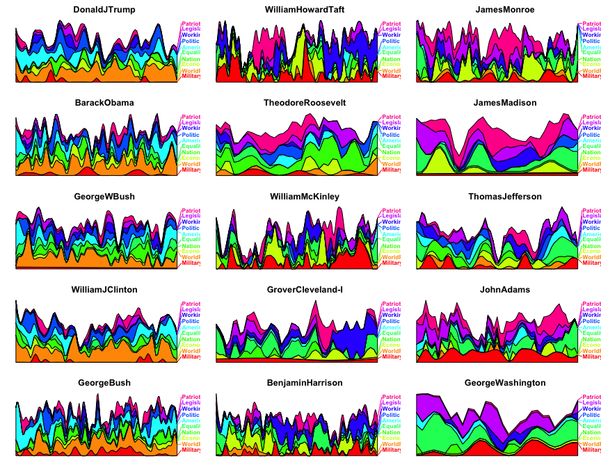

```r
for(i in 5:1){
  speech.df=tbl_df(corpus.list.df)%>%filter(File==founding_presidents[i],  Term==1)%>%
    select(sent.id, Military:Patriotism)
  speech.df=as.matrix(speech.df)
  speech.df[,-1]=replace(speech.df[,-1], speech.df[,-1]<1/15, 0.001)
  speech.df[,-1]=f.smooth.topic(x=speech.df[,1], y=speech.df[,-1])
  plot.stacked(speech.df[,1], speech.df[,topic.plot+1],
               xlab="Sentences", ylab="Topic share", main=founding_presidents[i])

}
```

Here we choice their most similar and most different topics *(“Military”, “WorldPeace”, “Economy”, “Equality”, “America”, “Legislation”,“Patriotism”)* to compare:

```r
# [1] "Military"  "WorldPeace"  "Time"  "Economy",
# [5] "Nation"  "Responsibility"  "Hope"  "Equality",
# [9] "America"  "Politic"  "WorkingFamilies"  "Legislation",
# [13] "Community"  "Government"  "Patriotism"
par(mfcol=c(5, 2), mar=c(1,1,2,0), bty="n", xaxt="n", yaxt="n")
topic.plot=c(1,2,4,8,9,12,15)
print(topics.hash[topic.plot])
```

```
[1] "Military"    "WorldPeace"  "Economy"     "Equality"    "America"     "Legislation" "Patriotism"
```

```r
recent_presidents <- c("GeorgeBush","WilliamJClinton","GeorgeWBush","BarackObama","DonaldJTrump")
founding_presidents <- c("GeorgeWashington","JohnAdams","ThomasJefferson","JamesMadison","JamesMonroe")
for(i in 5:1){
  speech.df=tbl_df(corpus.list.df)%>%filter(File==recent_presidents[i],  Term==1)%>%
    select(sent.id, Military:Patriotism)
  speech.df=as.matrix(speech.df)
  speech.df[,-1]=replace(speech.df[,-1], speech.df[,-1]<1/15, 0.001)
  speech.df[,-1]=f.smooth.topic(x=speech.df[,1], y=speech.df[,-1])
  plot.stacked(speech.df[,1], speech.df[,topic.plot+1],
               xlab="Sentences", ylab="Topic share", main=recent_presidents[i])

}
```

```
[1] 0.053289 0.106578 0.159867 0.213156 0.266445 0.319734 0.373023
[1] 0.06589376 0.13178752 0.19768128 0.26357504 0.32946880 0.39536256 0.46125632
[1] 0.06035184 0.12070368 0.18105553 0.24140737 0.30175921 0.36211105 0.42246290
[1] 0.05083403 0.10166805 0.15250208 0.20333611 0.25417013 0.30500416 0.35583819
[1] 0.05695428 0.11390856 0.17086283 0.22781711 0.28477139 0.34172567 0.39867995
```

```
[1] 0.06028618 0.12057237 0.18085855 0.24114473 0.30143091 0.36171710 0.42200328
[1] 0.05800118 0.11600237 0.17400355 0.23200473 0.29000591 0.34800710 0.40600828
[1] 0.06076781 0.12153563 0.18230344 0.24307125 0.30383906 0.36460688 0.42537469
[1] 0.07426302 0.14852604 0.22278906 0.29705208 0.37131510 0.44557812 0.51984114
[1] 0.06787026 0.13574053 0.20361079 0.27148106 0.33935132 0.40722159 0.47509185
```

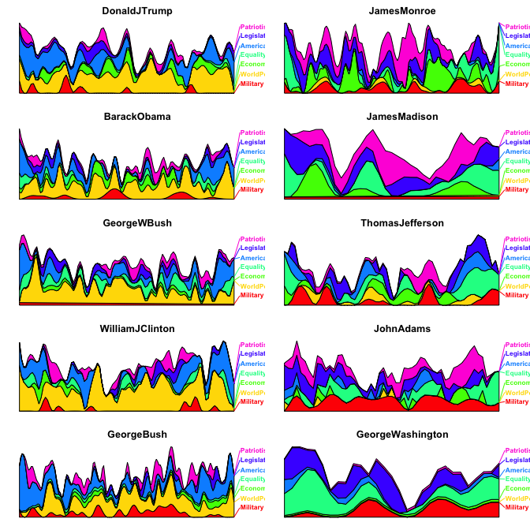

```r
for(i in 5:1){
  speech.df=tbl_df(corpus.list.df)%>%filter(File==founding_presidents[i],  Term==1)%>%
    select(sent.id, Military:Patriotism)
  speech.df=as.matrix(speech.df)
  speech.df[,-1]=replace(speech.df[,-1], speech.df[,-1]<1/15, 0.001)
  speech.df[,-1]=f.smooth.topic(x=speech.df[,1], y=speech.df[,-1])
  plot.stacked(speech.df[,1], speech.df[,topic.plot+1],
               xlab="Sentences", ylab="Topic share", main=founding_presidents[i])

}
```

Clearly, the new fashion and old fashion are very different! Compared with thier antecessors, recent presidents seems focus more on WorldPeace (international affairs) when giving their inaguraul speeches. However, the first founders of this counrty cares more about Legislation and Patriotism. Besides, even if they both mentioned Military in their speeches, their antecessors obviously pay more attention on it.

Then I will use wordCloud to show you the most frequently used words in those different time periods.

# Part 2- WordCloud and conclusion

## 2.1 WordCLoud

```r
par(mfrow=c(1,3), mar=c(0,0,0,0), bty="n", xaxt="n", yaxt="n", font.main=1)
folder.path="../data/inauguralSpeeches/"
recent_presidents <- c("GeorgeBush","WilliamJClinton","GeorgeWBush","BarackObama","DonaldJTrump")
middle_presidents <- c("BenjaminHarrison","GroverCleveland-I","WilliamMcKinley",
                       "TheodoreRoosevelt","WilliamHowardTaft")
founding_presidents <- c("GeorgeWashington","JohnAdams","ThomasJefferson","JamesMadison","JamesMonroe")
recent_locale <- paste(folder.path,"inaug",recent_presidents,"-1.txt",sep = "")
middle_locale <- paste(folder.path,"inaug",middle_presidents,"-1.txt",sep = "")
founding_locale <- paste(folder.path,"inaug",founding_presidents,"-1.txt",sep = "")
speechesCloud(recent_locale,150,color=brewer.pal(9,"Reds"))
speechesCloud(middle_locale,150,color=brewer.pal(9,"Greens"))
```

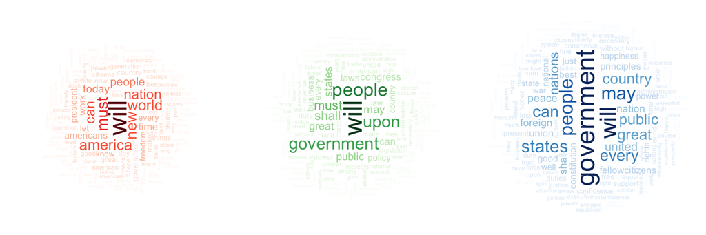

```r
speechesCloud(founding_locale,150,color=brewer.pal(9,"Blues"))
```

```r
par(mfrow=c(1,3), mar=c(0,0,0,0), bty="n", xaxt="n", yaxt="n", font.main=1)
speechesCloud(recent_locale,150,color=brewer.pal(9,"Reds"),rm.words = "will")
speechesCloud(middle_locale,150,color=brewer.pal(9,"Greens"),rm.words = "will")
```

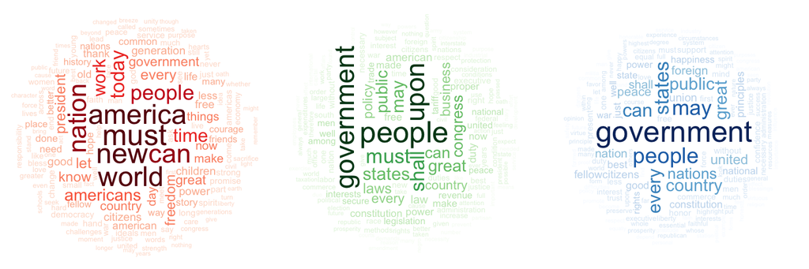

```r
speechesCloud(founding_locale,150,color=brewer.pal(9,"Blues"),rm.words = "will")
```

## 2.2 End of th story

From all above analysis, we can find something rapidly changed as time went by. When USA was just established, the biggest problem they face is building a system to keep the whole country runs well in a long term. So we can see the topics mentioned most by first 5 presidents are Legislation and Patriotism, which helps them establish the state order bring the people together. This is also the cornerstone of the rapid development of the USA.

Now, this country is no longer the new born from the War of Independence. US is now the most powerful country all over the world and has huge influence on this world than any other countries. So most recent inaguraul speeches focused more on international affairs than before. From the topics change of inagural speeches, we could see a great country ’s growing history with time trend.

But no matter how powerful the United States are, there are something unchanged: *People, Nation, America, Freedom，War* and many universal values. And I think that is why US became the superpower in such a short history. Any government should always be concerned with its people and their rights, for this is the source of superpower.